# STA141A Project Report

Victor Lu

2023-06-03

# 1 Abstract

The purpose of the project report is to understand and analyze this data about the neurons responses of mice and create a prediction model. It is important to know how the brain works and reacts to stimuli which is the main purpose from the original project. Procedures that are used in this project are filtering, development of new data structures, and clustering brain areas into groups for analysis in order to build a prediction model.

# 2 Introduction

For this dataset, we have a table where we have a summary of the dataset where columns: mouse, date of experiment, brain area, neurons, trials, and success rate. Description of each columns is listed, mouse: name of the mouse of experiment, date of experiment: gives year-month-day of experimentation, brain area: area of brain that is being checked, neurons: neurons, trails: number of times of experimentation, success rate: probability of success. Other variables listed that are not in the table are feedback type, contrast left and right, time, and spikes(spks). Description of these variables is as follows; feedback type: gives numeric value, 1 for success and -1 for failure, contrast left and right: comparison of left and right part of brain, time: shows time value in relative to spikes, spikes(spks): number of spikes of neurons in visual cortex in relative to time.

This is the data set

```r
# In package knitr
kable(meta, format = "html", table.attr = "class='table table-striped'",digits=2)
```

| mouse | date_exp | brain_area | neurons | trials | success_rate |
| --- | --- | --- | --- | --- | --- |
| Cori | 2016-12-14 | 8 | 734 | 114 | 0.61 |
| Cori | 2016-12-17 | 5 | 1070 | 251 | 0.63 |
| Cori | 2016-12-18 | 11 | 619 | 228 | 0.66 |
| Forssmann | 2017-11-01 | 11 | 1769 | 249 | 0.67 |
| Forssmann | 2017-11-02 | 10 | 1077 | 254 | 0.66 |
| Forssmann | 2017-11-04 | 5 | 1169 | 290 | 0.74 |
| Forssmann | 2017-11-05 | 8 | 584 | 252 | 0.67 |
| Hench | 2017-06-15 | 15 | 1157 | 250 | 0.64 |
| Hench | 2017-06-16 | 12 | 788 | 372 | 0.69 |
| Hench | 2017-06-17 | 13 | 1172 | 447 | 0.62 |
| Hench | 2017-06-18 | 6 | 857 | 342 | 0.80 |
| Lederberg | 2017-12-05 | 12 | 698 | 340 | 0.74 |
| Lederberg | 2017-12-06 | 15 | 983 | 300 | 0.80 |
| Lederberg | 2017-12-07 | 10 | 756 | 268 | 0.69 |
| Lederberg | 2017-12-08 | 8 | 743 | 404 | 0.76 |
| Lederberg | 2017-12-09 | 6 | 474 | 280 | 0.72 |
| Lederberg | 2017-12-10 | 6 | 565 | 224 | 0.83 |
| Lederberg | 2017-12-11 | 10 | 1090 | 216 | 0.81 |

> This table is important because it gives us a foundation of what the data is saying and seeing simple results from this table would help us with the analysis of the data and what we can do to manipulate it.

# 3 Background

The background for this report is that in this project, the source of data comes from researchers doing a study on the mice where they attempt to understand how vision, decision-making, and actions are correlated to different parts of the brain. The source of the data that the researchers collected was their own experimentation data. The target population is aiming towards true population coefficients that explain the feedback type. The sampling mechanism is rStudio. Description of these variables is as follows; feedback type: gives numeric value, 1 for success and -1 for failure, contrast left and right: comparison of left and right part of brain, time: shows time value in relative to spikes, spikes(spks): number of spikes of neurons in visual cortex in relative to time. The existing research that is relevant to this report is the use of machine learning and using it to read brain responses to stimuli.

# 4 Descriptive analysis

The descriptive analysis provides basic univariate descriptive statistics for relevant variables (mean, standard deviations, missing values, quantiles, etc.), and a few multivariate description of key variables. Readers that are familiar with this topic or statistics gain basic insights of this data set, e.g., being able to generate hypotheses, spot abnormality (or the lack of), propose statistical models, evaluate the plausibility of assumptions.

```r
spk.avg <- c()
for (i in 1:18) {
    length.trial = length(session[[i]]$spks)
  for (k in 1:length.trial) {
    spk.per = session[[i]]$spks[[k]]
    num.spk = apply(spk.per, 1, sum)
    spk.avg = c(spk.avg, mean(num.spk))
  }
}
```

> This code allows us to calculate the average spikes among all of the sessions. This is important becuase it gives us a good idea of that the mean is of the spike data.

```r
coriFeed <- c()
coriContLeft <- c()
coriContRight <- c()
for(i in 1:3){
  for(j in 1:length(session[[i]]$feedback_type)){
    coriFeed = c(coriFeed, session[[i]]$feedback_type[[j]])
    coriContLeft <- c(coriContLeft,session[[i]]$contrast_left[[j]])
    coriContRight <- c(coriContRight,session[[i]]$contrast_right[[j]])
  }
}

forssmannContLeft <- c()
forssmannContRight <- c()
forssmannFeed <- c()
for(i in 4:7) {
  for(j in 1:length(session[[i]]$feedback_type)){
    forssmannFeed = c(forssmannFeed,session[[i]]$feedback_type[[j]])
    forssmannContLeft <- c(forssmannContLeft,session[[i]]$contrast_left[[j]])
    forssmannContRight <- c(forssmannContRight,session[[i]]$contrast_right[[j]])
  }
}

henchContLeft <- c()
henchContRight <- c()
henchFeed <- c()
for(i in 8:11){
  for(j in 1:length(session[[i]]$feedback_type)){
    henchFeed = c(henchFeed, session[[i]]$feedback_type[[j]])
    henchContLeft <- c(henchContLeft,session[[i]]$contrast_left[[j]])
    henchContRight <- c(henchContRight,session[[i]]$contrast_right[[j]])
  }
}
lederbergContL <- c()
lederbergContR <- c()
lederbergFeed <- c()
for(i in 12:18){
  for(j in 1:length(session[[i]]$feedback_type)){
    lederbergFeed = c(lederbergFeed, session[[i]]$feedback_type[[j]])
    lederbergContL <- c(lederbergContL,session[[i]]$contrast_left[[j]])
    lederbergContR <- c(lederbergContR,session[[i]]$contrast_right[[j]])
  }
}

trialDifferences1 <- length(lederbergFeed)-length(coriFeed)
coriFeed <- c(coriFeed,rep.int(NA, times = trialDifferences1))
trialDifferences2 <- length(lederbergFeed)-length(forssmannFeed)
forssmannFeed <- c(forssmannFeed,rep.int(NA, times = trialDifferences2))
trialDifferences3 <- length(lederbergFeed)-length(henchFeed)
henchFeed <- c(henchFeed,rep.int(NA, times = trialDifferences3))

test.mouse.feedback <- data.frame(coriFeed,forssmannFeed,henchFeed,lederbergFeed)
```

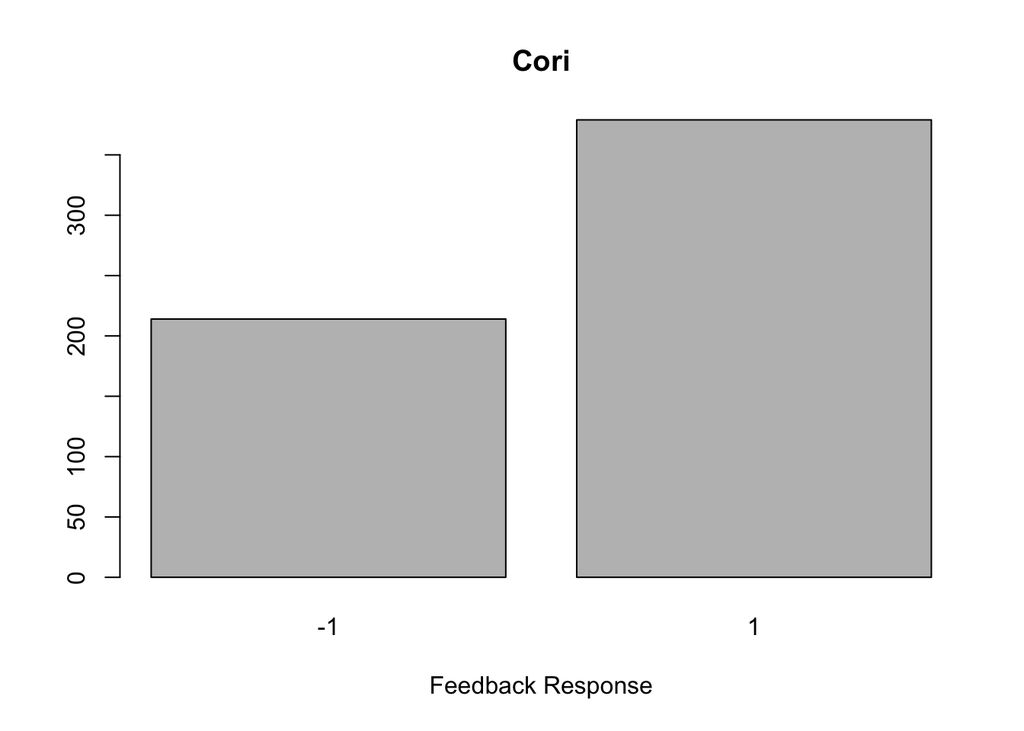

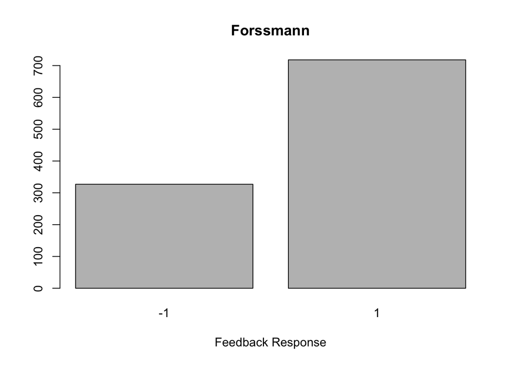

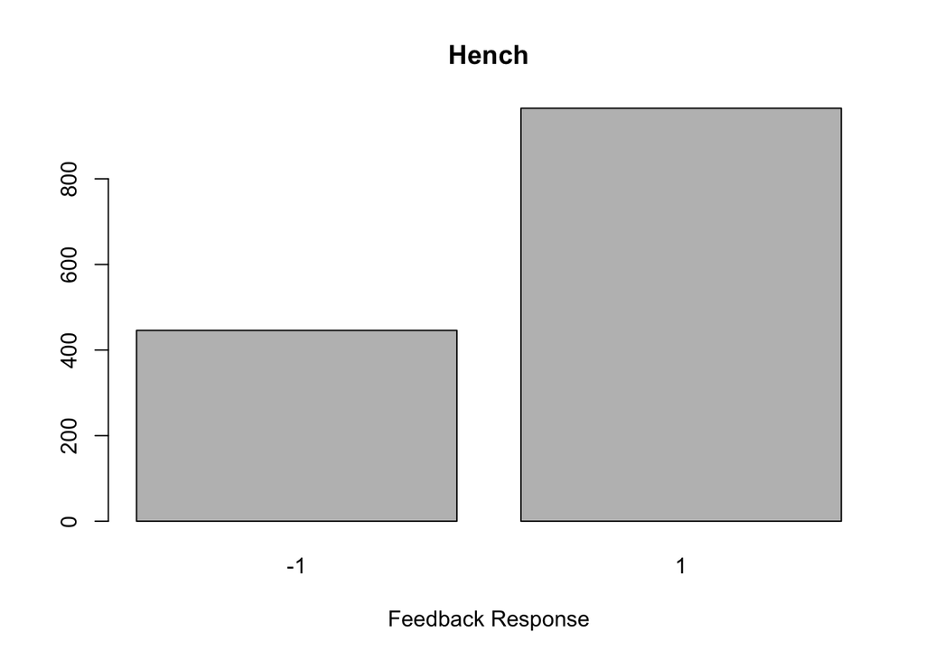

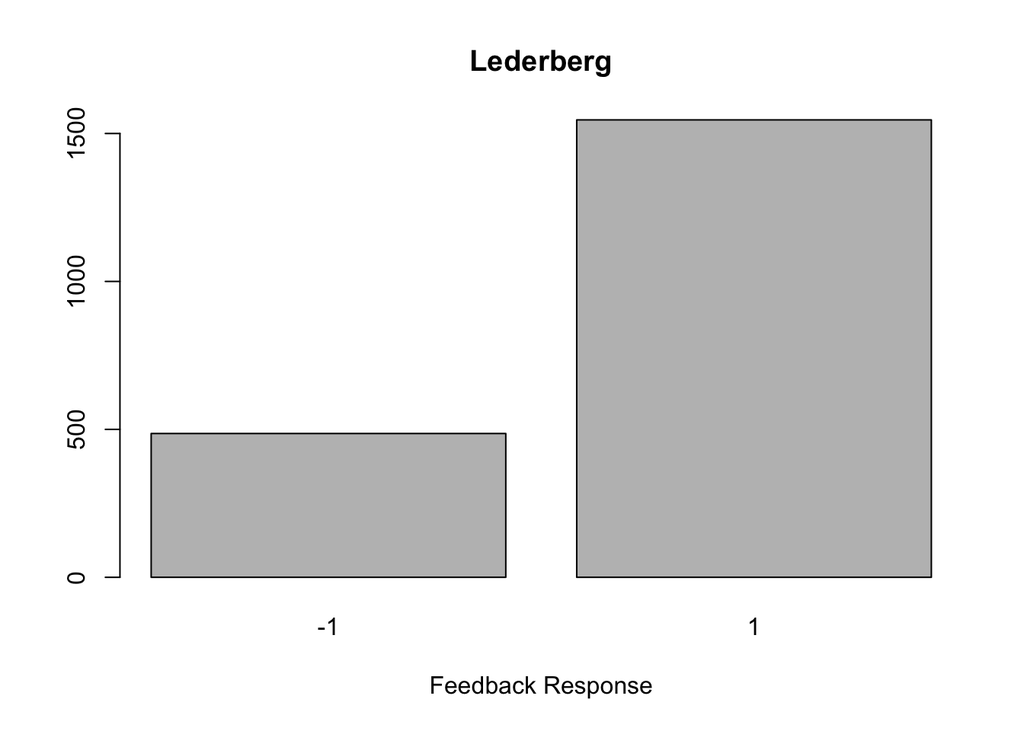

```r
for(i in 1:4) {
  namesMouse <- c("Cori", "Forssmann", "Hench", "Lederberg")
  feedbackResults = table(test.mouse.feedback[[i]])
  barplot(feedbackResults, main = namesMouse[i], xlab = "Feedback Response", ylab = NULL)
}
```

```r
neuroFunc <- function(fb){
  sessionSum <- list()
  for (m in 1:18){
    spks <- session[[m]][["spks"]]
    feed <- session[[m]][["feedback_type"]]
    trial <- 1:length(feed)
    feedTrials <- data.frame(feed,trial)
    filterFeed <- feedTrials %>% filter(feed %in% c(fb))
    dataList <- list()
    tempVec <- c()
    brainAve <- c(matrix(0,dim(spks[[1]])[1],1))
      for (l in 1:dim(spks[[1]])[1]){
       dataList[[l]] <-  rowSums(spks[[1]])[l] / 40
      }
  for (j in 2:length(spks)){
    for (i in 1:dim(spks[[1]])[1]){
      brainAve <- rowSums(spks[[j]])[i] / 40
      dataList[[i]] <- c(dataList[[i]], brainAve)
    }
  }
sessionSum[[m]] <- dataList
}
return(sessionSum) }
aveTotalNeuro <- neuroFunc(c(1,-1))
```

> This function overall is very important because the function is used to extract the total amount of neurons from each session which is a crucial part to how we are going to cluster brain area in relation to the number of neurons.

```r
brainLocation <- c()

n.session <- length(session)
for(i in 1:n.session){
  for(j in 1:length(session[[i]]$brain_area)){
    brainLocation <- c(brainLocation,session[[i]]$brain_area[[j]])
  }
}
#length(brainLocation)
```

> This code allowed us to take the data from the session and give us all of the brain areas.

```r
propActiveNeurons <- c()
for(i in 1:length(aveTotalNeuro)){
  for(j in 1:length(aveTotalNeuro[[i]])){
    temp = round(sum(!(aveTotalNeuro[[i]][[j]]==0))/length(aveTotalNeuro[[i]][[j]]),digits = 2)
    propActiveNeurons = c(propActiveNeurons,temp)
  }
}
```

> This chunk of code then allows us to use the brain areas found in the previous chunk in order to find the proportion of activation rates for each of the neurons.

```r
#This chunk allows us to show which brain areas are for which sessions
specficBrain <-length(brainNames)
brainPerSes <- matrix(, nrow = n.session, ncol =specficBrain)
colnames(brainPerSes) <- brainNames
rownames(brainPerSes) <- c(1:18)

for(i in 1:n.session){
  tempVal <- c(session[[i]]$brain_area)
  for(j in 1:specficBrain){
    brainPerSes[i,j] = comparisonBrain(tempVal,brainNames[j])
  }
}
head(brainPerSes)
```

```
##     ACA   MOs    LS  root  VISp   CA3   SUB    DG   CA1  VISl VISpm  POST VISam
## 1  TRUE  TRUE  TRUE  TRUE  TRUE  TRUE  TRUE  TRUE FALSE FALSE FALSE FALSE FALSE
## 2 FALSE FALSE FALSE  TRUE FALSE FALSE FALSE FALSE  TRUE  TRUE  TRUE  TRUE FALSE
## 3 FALSE FALSE FALSE  TRUE  TRUE FALSE FALSE  TRUE  TRUE FALSE FALSE  TRUE  TRUE
## 4  TRUE  TRUE FALSE FALSE  TRUE FALSE  TRUE  TRUE  TRUE FALSE FALSE FALSE FALSE
## 5  TRUE  TRUE FALSE  TRUE FALSE FALSE  TRUE  TRUE  TRUE FALSE FALSE FALSE FALSE
## 6 FALSE FALSE FALSE  TRUE FALSE FALSE FALSE FALSE  TRUE FALSE FALSE FALSE FALSE
##      MG   SPF    LP   MRN    NB   LGd    TH   VPL  VISa   LSr   OLF   ORB    PL
## 1 FALSE FALSE FALSE FALSE FALSE FALSE FALSE FALSE FALSE FALSE FALSE FALSE FALSE
## 2 FALSE FALSE FALSE FALSE FALSE FALSE FALSE FALSE FALSE FALSE FALSE FALSE FALSE
## 3  TRUE  TRUE  TRUE  TRUE  TRUE FALSE FALSE FALSE FALSE FALSE FALSE FALSE FALSE
## 4 FALSE FALSE FALSE FALSE FALSE  TRUE  TRUE  TRUE  TRUE  TRUE FALSE FALSE FALSE
## 5 FALSE FALSE FALSE FALSE FALSE FALSE FALSE FALSE  TRUE FALSE  TRUE  TRUE  TRUE
## 6 FALSE FALSE FALSE FALSE FALSE FALSE  TRUE FALSE FALSE FALSE FALSE FALSE FALSE
##     AUD   SSp    LD    CP   EPd   PIR   ILA    TT    PO  ORBm    MB   SCm  SCsg
```

[output cut: 20 more lines]

> This chunk allowed us to take every brain area(which also labels the names to the corresponding brain area) that was used throughout all of the sessions and then categorize it in to a logical variable where it would show if that area of the brain is used in that session.

```r
#This is the variance of the proportions for propAreaNeurons
neuroVar <- c()
for(i in 1:length(aveTotalNeuro)){
  for(j in 1:length(aveTotalNeuro[[i]])){
    neuroVar = c(neuroVar, var(aveTotalNeuro[[i]][[j]]))
  }
}

#This is the average of the proportions propAreaNeurons
neuroAverage <- c()
for(i in 1:length(aveTotalNeuro)){
  for(j in 1:length(aveTotalNeuro[[i]])){
    neuroAverage <- c(neuroAverage, mean(aveTotalNeuro[[i]][[j]]))
  }
}
```

```r
numNeuron <- c(1:length(brainLocation))

brainNeuroArea <- data.frame(brainLocation, propActiveNeurons, neuroAverage, neuroVar)
```

> This is the new data frame which merges all of the previous data about the brain locations, proportions of activation neurons, averages of those neurons, and variances.

```r
brainMostFreq <- brainNeuroArea %>%
  filter(brainLocation == "ACA" | brainLocation == "root" | brainLocation == "DG" | brainLocation == "MOs" | brainLocation == "Visp" | brainLocation == "CA3") %>%
  mutate(sumSquareProp = ((propActiveNeurons - mean(propActiveNeurons)) ^ 2))
```

# 5 Data integration

Part 2 (15 points). Data integration. Using the findings in Part 1, we will propose an approach to combine data across trials by (i) extracting the shared patters across sessions and/or (ii) addressing the differences between sessions. The goal of this part is to enable the borrowing of information across sessions to enhance the prediction performance in Part 3.

**For the course project, if students choose not to conduct any sophisticated methods for data integration, they can choose to focus on utilizing the behavioural information. For instance, they can start by recognizing the different rewarding mechanisms (0-0, equal but non-zero, unequal), the time since the start of the experiment, session IDs for the same mouse, etc.**

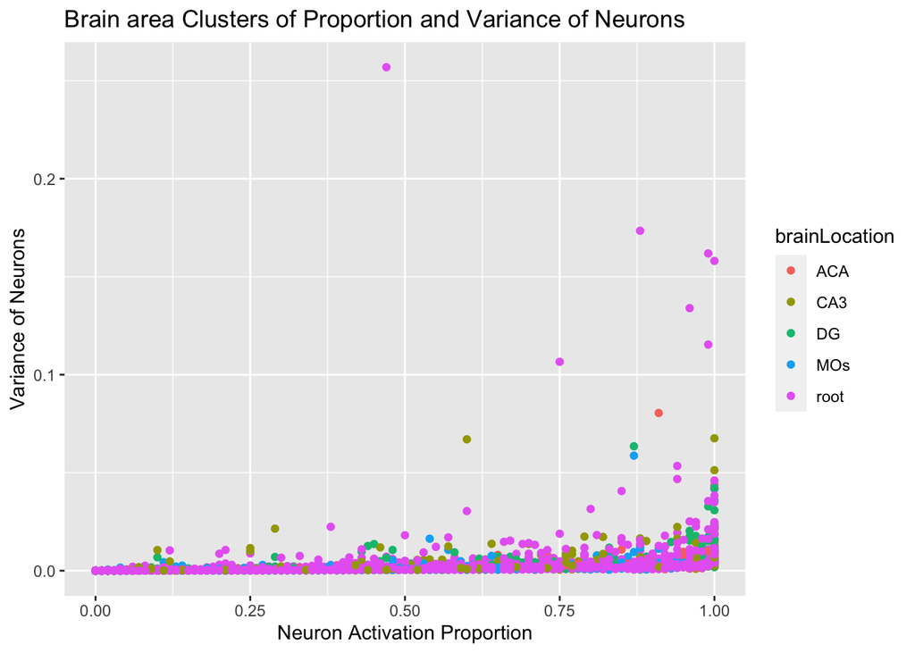

```r
#plot of the 6 brain areas where the brain areas are a cluster
brainMostFreq %>% ggplot(aes(x = propActiveNeurons, y = neuroVar, color = brainLocation)) +
  geom_point()+
  labs(title = "Brain area Clusters of Proportion and Variance of Neurons",
       x = "Neuron Activation Proportion", y = "Variance of Neurons")
```

> For this plot, it is a relationship between the neuron activation proportion and variance of neurons. We can see that throughout the brain areas, they are very similar to each other but are stacked up on top of each other which makes it difficult to see the other colors that are underneath it.

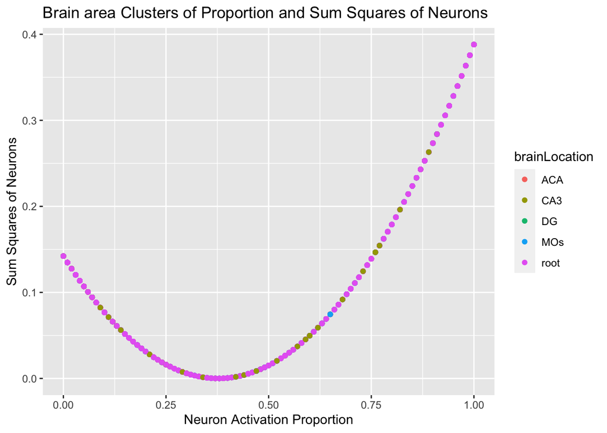

```r
#plot the 3 groups
brainMostFreq %>% ggplot(aes(x = propActiveNeurons, y = sumSquareProp, color = brainLocation)) +
  geom_point()+
  labs(title = "Brain area Clusters of Proportion and Sum Squares of Neurons",
       x = "Neuron Activation Proportion", y = "Sum Squares of Neurons")
```

> This plot is the a relationship between the neuron activation proportion and sum square of neurons . We can see that throughout the brain areas, we have the same thing where they are stacked on top of each other but in this case, because of the y-axis being the sum square, it seemed to have created a parabola. This plot could possibly be useful to show homogeneity due to all the points lining up.

# 6 Predictive modeling

```r
# This is the gathering data of feedback type and contrast left/right
feedback <- c()
contLeft <- c()
contRight <- c()

w <- c(1,1,1,1)
sessionsAll <- c(w*1,w*2,w*3,w*12,w*13,w*14,w*15,w*16,w*17,w*8,c(1:18))
for (s in sessionsAll){

  feedback <- append(feedback, session[[s]][["feedback_type"]] == 1)
  contLeft <- append(contLeft, session[[s]][["contrast_left"]])
  contRight <- append(contRight, session[[s]][["contrast_right"]])

}
contrastTable <- data.frame(feedback, contLeft, contRight)

lengthDiff <- length(propActiveNeurons) - dim(contrastTable)[1]
feedback <- c(contrastTable$feedback, rep(NA, lengthDiff))
contLeft <- c(contrastTable$contLeft, rep(NA, lengthDiff))
contRight <- c(contrastTable$contRight, rep(NA, lengthDiff))


lengthDiff2 <- length(propActiveNeurons) - length(neuroAverage)
neuroAverage <- c(neuroAverage, rep(NA, lengthDiff2))
neuroVar <- c(neuroVar, rep(NA, lengthDiff2))

lengthDiff3 <- length(propActiveNeurons) - length(spk.avg)
spk.avg <- c(spk.avg, rep(NA, lengthDiff3))

contrastTable <- data.frame(feedback, contLeft, contRight, propActiveNeurons, neuroAverage, neuroVar, spk.avg)
```

> This is our training data where we use this to test our prediction model.

```r
#This is a glm table of contrast left/right vs feedback type
contrastTable.glm <- glm(contrastTable$feedback ~ contrastTable$contLeft + contrastTable$contRight + contrastTable$propActiveNeurons, data = contrastTable, family = "binomial")

summary(contrastTable.glm)
```

```
##
## Call:
## glm(formula = contrastTable$feedback ~ contrastTable$contLeft +
##     contrastTable$contRight + contrastTable$propActiveNeurons,
##     family = "binomial", data = contrastTable)
##
## Coefficients:
##                                 Estimate Std. Error z value Pr(>|z|)
## (Intercept)                      0.81433    0.03504  23.243   <2e-16 ***
## contrastTable$contLeft           0.38817    0.04641   8.364   <2e-16 ***
## contrastTable$contRight         -0.00329    0.04512  -0.073    0.942
## contrastTable$propActiveNeurons -0.03372    0.05613  -0.601    0.548
## ---
## Signif. codes:  0 '***' 0.001 '**' 0.01 '*' 0.05 '.' 0.1 ' ' 1
##
## (Dispersion parameter for binomial family taken to be 1)
##
##     Null deviance: 18752  on 15716  degrees of freedom
## Residual deviance: 18679  on 15713  degrees of freedom
##   (588 observations deleted due to missingness)
## AIC: 18687
##
## Number of Fisher Scoring iterations: 4
```

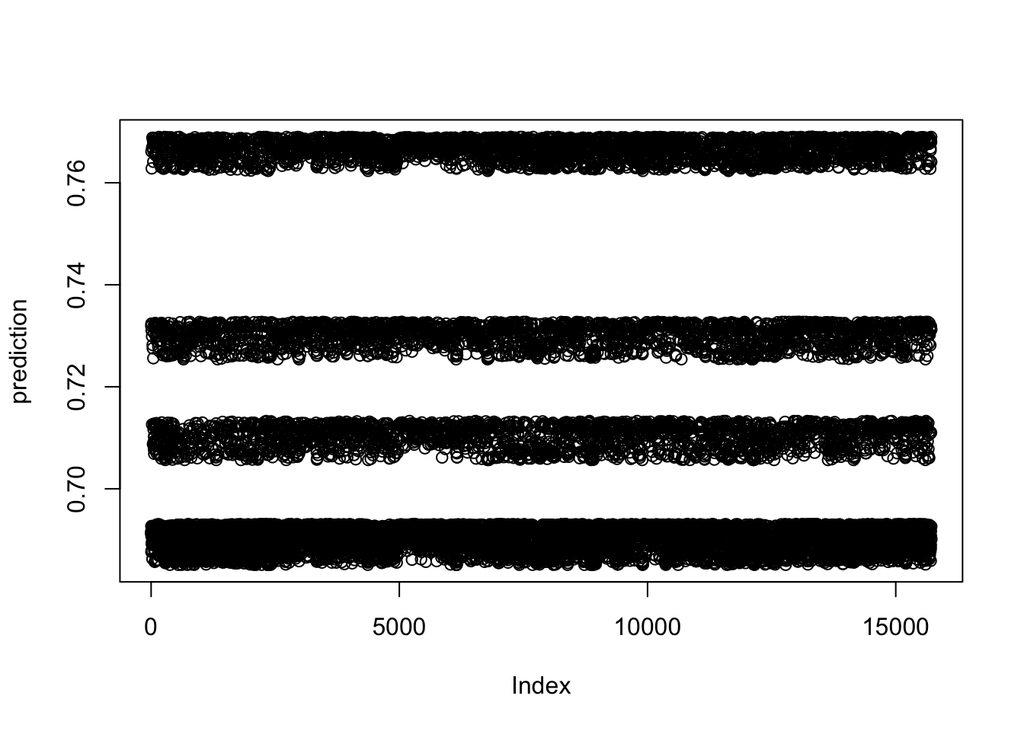

```r
prediction <- predict(contrastTable.glm, contrastTable =  contrastTable, type = "response")
plot(prediction)
```

> This is the glm function where we could add our training data into it to train the model.

```r
neuroAveVarDf <- c("propActiveNeurons", "neuroAverage", "neuroVar", "contLeft", "contRight", "feedback", "spk.avg")
pcaData <-  contrastTable %>%
            select(all_of(neuroAveVarDf)) %>%
              na.omit()

pcaTableResult <- prcomp(pcaData, scale = TRUE)

summary(pcaTableResult)
```

```
## Importance of components:
##                           PC1    PC2    PC3    PC4    PC5     PC6     PC7
## Standard deviation     1.4815 1.0875 1.0044 0.9856 0.9134 0.80637 0.39724
## Proportion of Variance 0.3135 0.1689 0.1441 0.1388 0.1192 0.09289 0.02254
## Cumulative Proportion  0.3135 0.4825 0.6266 0.7654 0.8846 0.97746 1.00000
```

```r
pcaTableResult$rotation
```

```
##                            PC1         PC2          PC3           PC4
## propActiveNeurons  0.513997350  0.01805769  0.006730647 -0.0253618980
## neuroAverage       0.640906414 -0.03002435  0.034842973  0.0000971397
## neuroVar           0.566350491 -0.05067788  0.045650708  0.0213731193
## contLeft          -0.008553217 -0.67313907 -0.201591124  0.0774951865
## contRight          0.034913169  0.33051656 -0.389914064  0.8516297442
## feedback          -0.029534214 -0.65730927 -0.052179438  0.3203622090
## spk.avg           -0.046135203 -0.04232419  0.895132407  0.4061887299
##                            PC5           PC6           PC7
## propActiveNeurons -0.001658522 -0.7845843986  0.3452776958
## neuroAverage      -0.002352765  0.0843258121 -0.7615819635
## neuroVar           0.021885145  0.6107932958  0.5482614943
## contLeft          -0.706886060 -0.0193621866  0.0101665328
## contRight         -0.110598474 -0.0006492139 -0.0011095864
## feedback           0.677546620 -0.0506691392 -0.0089907294
## spk.avg           -0.168888742 -0.0361296467  0.0003698001
```

> This chunkc formats the data, perfroms PCA, and makes the summary of PCA for our prediction model

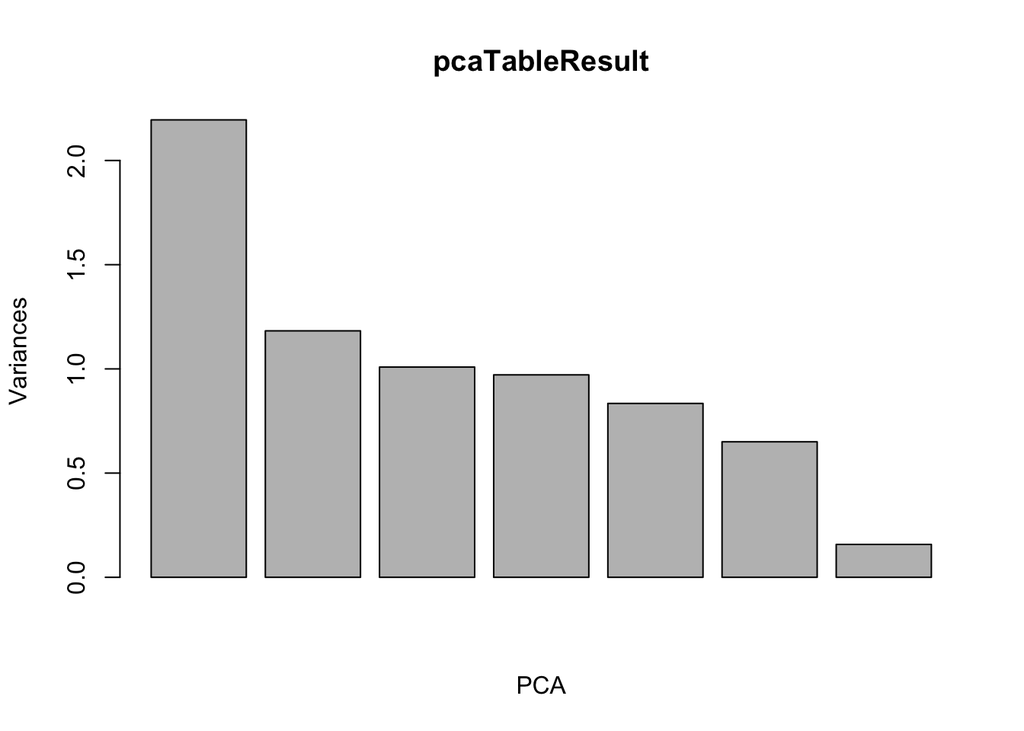

```r
varExplanation <- pcaTableResult$sdev^2 / sum(pcaTableResult$sdev^2)
varAll <- cumsum(varExplanation)

plot(pcaTableResult, xlab = "PCA")
```

> This plot shows the relationship between the PCA and variance which shows to be significant because you can see which components are essentially useful for the prediction model.